# Music and Song Analysis for Music Streaming Company

As a consulting firm in the field of data analysis, we were able to secure a project with a music streaming service, which is a relatively new entrant in the market. They are currently our client, and they want to know where they need to improve in order to compete in the market and also they want to improve their recommendation system and further. They need to know how people listen to music in the music industry. They have a large dataset with 20 features, and they have some specific requests for us.

That music streaming company wants to know some answers from that dataset. Those are that we need to answer to complete our task for that music streaming company:

1. What audio features are most correlated with song popularity?
2. Do energetic songs tend to be more popular?
3. Please show the relationship between danceability and popularity
4. Which genres have the highest average tempo?
5. How does song duration affect popularity across different duration ranges?
6. How do audio features differ across genres?
7. Can we identify clusters of songs based on their audio features?

**Dataset Characteristics**

The dataset used for this analysis is a structured dataset with approx. 114,000 songs and 20 features. Each record in the dataset represents a unique music track, while each feature represents a particular attribute of the track.

From our data science point of view, this dataset is a multivariate dataset. This means that there are various variables representing different attributes of each record. The variables in this dataset have different types: numerical and categorical. Data Types The dataset contains different variables, including:

- **Numerical features:** This dataset contains several variables related to audio, such as:
  - danceability
  - energy
  - loudness
  - tempo
  - acousticness
  - instrumentalness
  - popularity

  **Categorical features:** This dataset contains variables such as:
  - track_name
  - artists
  - album_name
  - track_genre

  **Domain of Features** The given dataset contains 'audio signal processing features', and these features are extracted from the songs. They are used in music analytics and recommendation systems. The features used in this dataset are:
- Danceability: This feature measures how suitable a song is for dancing.
- Energy: This feature measures the energy present in a song. (Mostly looking for higher BPM's )
- Valence: This feature measures the happy or sad lyrics or rythmes in a song.
- Acousticness: This feature measures the probability of a song being an acoustic song.
- Speechiness: This feature measures the presence of spoken words in a song.
- Instrumentalness: This feature measures the probability of the presence of vocals in a song.

**The given dataset may have the following problems:**

- Missing Values,
- Duplicate Values,
- Class Imbalance,

This is why we should pre process our data first.

**Uploading the Dataset**

```python
from google.colab import files
uploaded = files.upload()
```

Upload widget is only available when the cell has been executed in the current browser session. Please rerun this cell to enable.

```
Saving spotify-tracks-dataset-detailed (1).csv to spotify-tracks-dataset-detailed (1).csv
```

**1. Data Exploration**

```python
import pandas as pd

df = pd.read_csv("spotify-tracks-dataset-detailed (1).csv")

df.head()
df.shape
df.info()
df.describe()
df.isnull().sum()
```

```
<class 'pandas.core.frame.DataFrame'>
RangeIndex: 114000 entries, 0 to 113999
Data columns (total 20 columns):
 #   Column            Non-Null Count   Dtype
---  ------            --------------   -----
 0   track_id          114000 non-null  object
 1   artists           113999 non-null  object
 2   album_name        113999 non-null  object
 3   track_name        113999 non-null  object
 4   popularity        114000 non-null  int64
 5   duration_ms       114000 non-null  int64
 6   explicit          114000 non-null  bool
 7   danceability      114000 non-null  float64
 8   energy            114000 non-null  float64
 9   key               114000 non-null  int64
 10  loudness          114000 non-null  float64
 11  mode              114000 non-null  int64
 12  speechiness       114000 non-null  float64
 13  acousticness      114000 non-null  float64
 14  instrumentalness  114000 non-null  float64
 15  liveness          114000 non-null  float64
 16  valence           114000 non-null  float64
 17  tempo             114000 non-null  float64
 18  time_signature    114000 non-null  int64
 19  track_genre       114000 non-null  object
dtypes: bool(1), float64(9), int64(5), object(5)
memory usage: 16.6+ MB
```

|  | 0 |
| --- | --- |
| track_id | 0 |
| artists | 1 |
| album_name | 1 |
| track_name | 1 |
| popularity | 0 |
| duration_ms | 0 |
| explicit | 0 |
| danceability | 0 |
| energy | 0 |
| key | 0 |
| loudness | 0 |
| mode | 0 |
| speechiness | 0 |
| acousticness | 0 |
| instrumentalness | 0 |
| liveness | 0 |
| valence | 0 |
| tempo | 0 |
| time_signature | 0 |
| track_genre | 0 |

**dtype:** int64

In this step, we explored our dataset to get a sense of its structure and characteristics. We have examined the number of rows and columns in our dataset and identified the type of our data which will be helpful to move forward while we are cleaning and classifiying our data. We have also calculated summary statistics and identified missing values. This step has given us a good understanding of our data.

**2. Data Preprocessing**

```python
df.duplicated().sum()
df = df.drop_duplicates()
df = df.dropna()
df.shape
df["popularity"] = df["popularity"].astype(int)
df["duration_ms"] = df["duration_ms"].astype(int)
df["artists"] = df["artists"].str.lower()
df["track_name"] = df["track_name"].str.lower()
df = df.drop(columns=["track_id", "album_name"], errors='ignore')
numeric_df = df.select_dtypes(include=["int64", "float64"])
print("\n shape:", df.shape)
print("\n Numeric ones:", numeric_df.columns)
```

[output not shown]

In this step, the dataset was prepared for further analysis by performing a series of cleaning activities.

Firstly, duplicate rows were identified and eliminated from the dataset.

Next, missing values were identified and eliminated by checking for null values.

The data type of each column was also examined and formatted as required.

Text data such as artist and track names were formatted by converting them to lowercase.

Irrelevant columns such as track_id and album_name were eliminated to simplify the dataset.

Finally, numerical features were separated from the dataset for further analysis.

This ensures that the dataset is clean and ready for further reliable analysis.

**Most Interesting Metadata**

"Popularity" is the most interesting metadata to their music streaming business:

This is the most important feature and is central to most of the questions our client wants to answer. Audio Features (danceability, energy, acousticness, instrumentalness, valence, tempo, loudness, speechiness): These features represent the core of the metadata and are central to most of the questions our client wants to answer. These features represent the objective characteristics of the music. The relationships between popularity and audio features, as well as relationships between audio features, can be extremely insightful and can point to trends in popular music. track_genre: This feature is extremely important and can provide a lot of insights into trends within a given genre of music. It will be particularly important when answering questions regarding genre-specific features such as tempo. artists and track_name: Although track_name was converted to lowercase and album_name was removed as it was not necessary, artists and track_name are fundamental features and are important when trying to understand performance by artists. duration_ms: The length of a song is important and can impact the popularity of a song.

**3. Starting to Analyse and Answering the Questions**

**3.1 What audio features are most correlated with song popularity?**

This would also help the company improve the quality of their playlists.

If we can identify the characteristics of popular music, we can provide more popular music for the user to listen to.

[figure not shown]

[figure not shown]

```python
import seaborn as sns
import matplotlib.pyplot as plt

corr_matrix = numeric_df.corr()
pop_corr = corr_matrix["popularity"].sort_values(ascending=False)
pop_corr

plt.figure(figsize=(10,6))
sns.heatmap(corr_matrix, cmap="coolwarm")
plt.title("Correlation Matrix of Audio Features")
plt.show()

plt.figure(figsize=(8,5))

pop_corr.drop("popularity").plot(kind="bar")

plt.title("Correlation of Features with Popularity")
plt.ylabel("Correlation Value")
plt.show()
```

Firstly, we checked the correlation matrix to understand the correlation between the various numerical variables.

Secondly, we looked on the correlation between the features and popularity.

Finally, we visualized the results using a heatmap and a bar chart for better interpretation.

From this analysis, we see that some features have a higher relationship with popularity than others.

However, this is not a very strong correlation, which suggests that popularity is influenced by a number of factors.

**3.2 Do energetic songs tend to be more popular?**

Energy is an important feature that indicates the intensity and activity level of a song.

Knowing that popular songs with higher energy levels are more popular will help the company make a more interesting playlist.

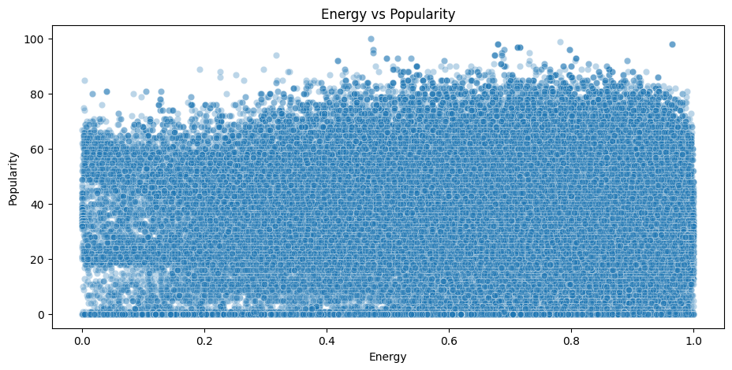

```python
plt.figure(figsize=(11,5))
sns.scatterplot(data=df, x="energy", y="popularity", alpha=0.3)

plt.title("Energy vs Popularity")
plt.xlabel("Energy")
plt.ylabel("Popularity")

plt.show()
```

In that code block, we used a "scatter plot" to visualize the relationship between the energy level of the songs and their popularity. Each point on the scatter plot represents a song, where the x-axis represents the energy level, and the y-axis represents the popularity of the song. We also used the transparency parameter which is named alpha=0.3 for a better visual representation.

The relationship is not very strong. High-energy songs are popular, but there are also many low-energy popular songs.

Thus, we can notice that energy is not a critical factor for popularity.

For the company:

- Energetic songs can be used for active playlists
- However, we should not use this feature for recommendation systems based on energy levels

Using other features, such as danceability and valence, can improve recommendation systems.

**3.3 The Relationship Between Danceability and Popularity**

Danceability refers to the ability of a song to be used for dancing, which is one of the key factor for user engagement.

Knowing its relationship with popularity can help the company produce a more engaging playlist, especially for entertainment purposes.

```python
low_dance = df[df["danceability"] < 0.5]
high_dance = df[df["danceability"] >= 0.5]

low_avg = low_dance["popularity"].mean()
high_avg = high_dance["popularity"].mean()

print("Low danceability avarage popularity:", low_avg)
print("High danceability avarage popularity:", high_avg)
```

```
Low danceability avarage popularity: 32.19954233409611
High danceability avarage popularity: 33.87131563792472
```

We categorized the songs based on the level of danceability, which was divided into less likely and more likely.

Then, we computed the average popularity for each category and compared the results using a bar chart.

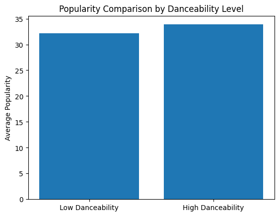

```python
plt.bar(["Low Danceability", "High Danceability"], [low_avg, high_avg])

plt.title("Popularity Comparison by Danceability Level")
plt.ylabel("Average Popularity")

plt.show()
```

For the company:

- Danceable tracks can be at the first place in the popular playlists
- Danceability can be used as a simple indicator for the selection of the tracks for the general audience. Not very strong alone as well.

**3.4 Which genres have the highest average tempo?**

We sorted the results to identify which genres have the highest tempo values and basically we visualized the top 10 genres using a horizontal bar chart to improve readability.

```python
tempo_by_genre = df.groupby("track_genre")["tempo"].mean()
tempo_by_genre = tempo_by_genre.sort_values(ascending=False)
tempo_table = tempo_by_genre.reset_index()
tempo_table.head(15)
```

|  | track_genre | tempo |
| --- | --- | --- |
| 0 | drum-and-bass | 155.254644 |
| 1 | happy | 152.920876 |
| 2 | hardstyle | 146.905859 |
| 3 | forro | 140.350656 |
| 4 | j-idol | 136.098086 |
| 5 | power-pop | 134.603671 |
| 6 | dubstep | 133.663397 |
| 7 | punk | 133.609122 |
| 8 | trance | 133.287026 |
| 9 | breakbeat | 133.042200 |
| 10 | punk-rock | 132.219025 |
| 11 | party | 131.323091 |
| 12 | metalcore | 130.580195 |
| 13 | dub | 129.506597 |
| 14 | grunge | 129.337903 |

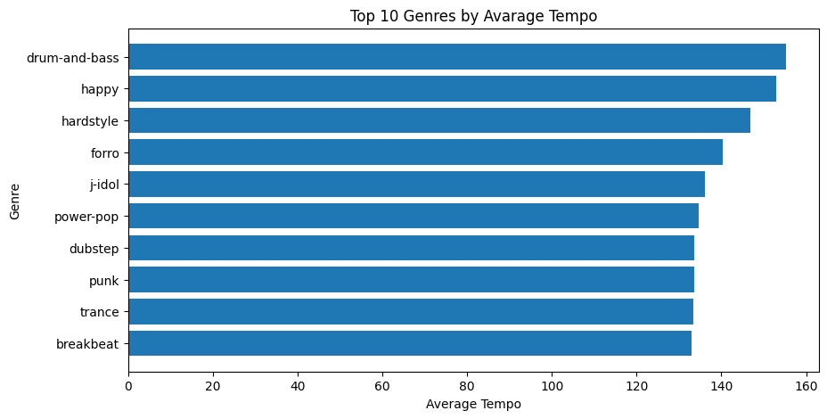

```python
top_10 = tempo_table.head(10)

plt.figure(figsize=(10,5))

plt.barh(top_10["track_genre"], top_10["tempo"])

plt.title("Top 10 Genres by Avarage Tempo")
plt.xlabel("Average Tempo")
plt.ylabel("Genre")

plt.gca().invert_yaxis()

plt.show()
```

For the company:

- High-tempo genres can be recommended for active situations (such as workouts)
- Low-tempo genres can be recommended for relaxation or chill playlists

**3.5 How does song duration affect popularity across different duration ranges?**

Song duration is an essential factor that affects user engagement.

Understanding how song length contributes to popularity gonna help the company improve their user retention by providing recommendations for sure.

```python
df["duration_min"] = df["duration_ms"] / 60000
bins = [0, 2, 3, 4, 5, 10]
labels = ["Very Short (<2 min)", "Short (2-3 min)", "Medium (3-4 min)", "Long (4-5 min)", "Very Long (5+ min)"]

df["duration_group"] = pd.cut(df["duration_min"], bins=bins, labels=labels)

duration_analysis = df.groupby("duration_group")["popularity"].mean().reset_index()

duration_analysis
```

|  | duration_group | popularity |
| --- | --- | --- |
| 0 | Very Short (<2 min) | 28.623133 |
| 1 | Short (2-3 min) | 32.215016 |
| 2 | Medium (3-4 min) | 34.751663 |
| 3 | Long (4-5 min) | 34.775890 |
| 4 | Very Long (5+ min) | 31.405776 |

At first, we changed the unit of the duration of the songs from milliseconds to minutes for better interpretation.

Next, we divided the songs based on their duration using a technique called binning which I choose to use because: Binning was used for this purpose, which converted the continuous data for the duration variable into ranges.

This is because the duration variable has a lot of unique values, and if we were to analyze this variable, it would be very difficult to establish any meaningful patterns.

By binning the data for the songs, we make the data easier to analyze so it is being able to establish some trends regarding the popularity of the songs. This helped us categorize the songs based on their duration, such as short, medium, and long songs.

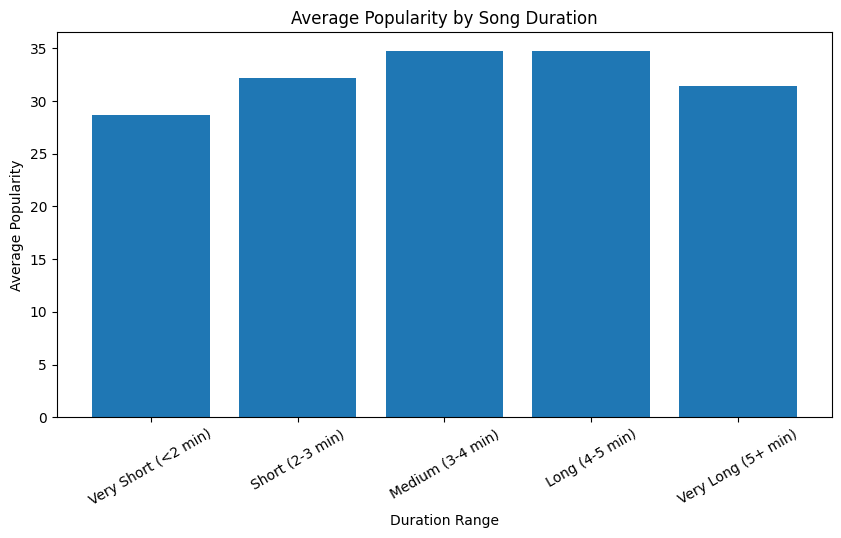

```python
plt.figure(figsize=(10, 5))
plt.bar(duration_analysis["duration_group"], duration_analysis["popularity"])

plt.title("Average Popularity by Song Duration")
plt.xlabel("Duration Range")
plt.ylabel("Average Popularity")

plt.xticks(rotation=30)

plt.show()
```

In the end we see that The length of the song is also important in engaging users.

For the company:

- Songs with a length of around 3-4, 4-5 minutes should be prioritized.
- Very short or long songs may not be very engaging for the masses.

**3.6 How do audio features differ across genres?**

This time again company wants to be sure that which features should they look for further recommendations, they want to see the intersected areas and also want to see everything in one graph.

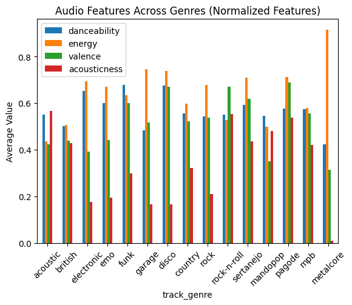

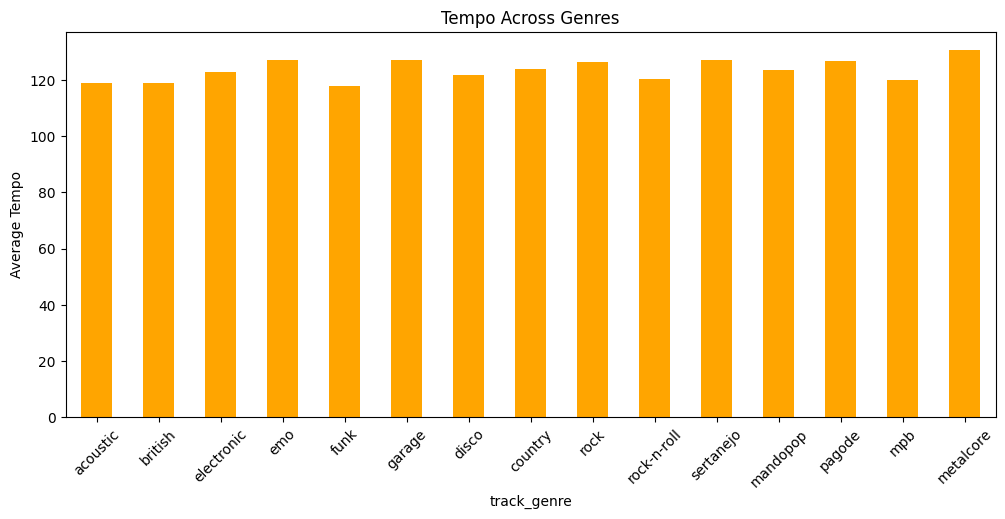

```python
features = ["danceability", "energy", "valence", "acousticness"]
tempo_feature = ["tempo"]

genre_features = df.groupby("track_genre")[features + tempo_feature].mean()

top_genres = df["track_genre"].value_counts().head(15).index
filtered = genre_features.loc[top_genres]

plt.figure(figsize=(12,5))
filtered[features].plot(kind="bar")

plt.title("Audio Features Across Genres (Normalized Features)")
plt.ylabel("Average Value")
plt.xticks(rotation=45)

plt.show()

plt.figure(figsize=(12,5))
filtered["tempo"].plot(kind="bar", color="orange")

plt.title("Tempo Across Genres")
plt.ylabel("Average Tempo")
plt.xticks(rotation=45)

plt.show()
```

We showed two different graphs because tempo and the others interval are not the same (0-200, 0-1) We showed that for just 15 type of genres to visualize better. It is up to them to see more.

For Company:

- Energetic genres can be recommended for active contexts
- Acoustic genres can be used for relaxation playlists
- Danceable genres can be prioritized for social settings

**3.7 Can we identify clusters of songs based on their audio features?**

Clustering can help group of songs with similar characteristics.

Then the company can:

- Create better playlists
- Improve recommendation systems
- Understand different types of songs in the catalog

Our goal is find the combination (energy + danceability + valence) and detect which one makes the song more popular.

```python
df["energy_level"] = pd.qcut(df["energy"], q=3, labels=["Low", "Medium", "High"])
df["dance_level"] = pd.qcut(df["danceability"], q=3, labels=["Low", "Medium", "High"])
df["valence_level"] = pd.qcut(df["valence"], q=3, labels=["Low", "Medium", "High"])

segment_analys = df.groupby(
    ["energy_level", "dance_level", "valence_level"]
)["popularity"].mean().reset_index()


top_segments = segment_analys.sort_values(by="popularity", ascending=False)

print("\nTop Feature Combinations:\n")
print(top_segments.head(10))
```

```
Top Feature Combinations:

   energy_level dance_level valence_level  popularity
6           Low        High           Low   40.875431
3           Low      Medium           Low   40.354590
12       Medium      Medium           Low   40.354385
13       Medium      Medium        Medium   39.749896
7           Low        High        Medium   39.339253
9        Medium         Low           Low   39.297161
10       Medium         Low        Medium   38.794410
15       Medium        High           Low   37.672854
16       Medium        High        Medium   37.331429
4           Low      Medium        Medium   36.842459
```

In this code block, we have chosen to use a segmentation based approach. Also some machine learning tools could be used to clustering.

Firstly, we have converted the continuous audio features into categorical levels by using the binning approach for features like energy, danceability, and valence. This has allowed us to compare the data more effectively.

Secondly, we have grouped the entire dataset according to the levels of the features and computed the average popularity for the entire group.

Thirdly, we have created pivot tables for analyzing the interactions between the features.

Finally, we have looked at the top 10% popular songs and analyzed the average values for the features to understand the typical profile for a popular song.

Sorting the songs into categories then looking at the combinations after that we find the most popular combination in this code block above.

```python
table_ = pd.pivot_table(

    df,
    values="popularity",
    index="energy_level",
    columns="dance_level",
    aggfunc="mean"
)

print("\nPopularity by Energy & Danceability:\n")
print(table_.round(2))


determining_threshold = df["popularity"].quantile(0.9)

best_songs = df[df["popularity"] >= determining_threshold]

top_profile = best_songs[
    ["energy", "danceability", "valence", "acousticness", "tempo"]
].mean()

print("\nTop Songs Feature Profile:\n")
print(top_profile.round(2))
```

```
Popularity by Energy & Danceability:

dance_level     Low  Medium   High
energy_level
Low           32.45   37.01  38.08
Medium        38.60   38.68  35.92
High          32.68   35.18  32.29

Top Songs Feature Profile:

energy            0.65
danceability      0.60
valence           0.49
acousticness      0.26
tempo           120.88
dtype: float64
```

First, we determine “how the features work together” and identify the most popular song profile.

Row = energy

Column = danceability.

We analyzed the two features together and observed interaction We analyzed the two features together and observed interaction We rounded the values for a cleaner look

Why 10%? Because:

We wanted to see the most successful ones “hit song” analysis

The popularity is a result of a combination of multiple audio features rather than a single one.

If a song is both medium in energy and danceability (**38.68** as a result we see from the result above), it is likely that the popularity of the song is high.

We tried to groupe continuous variables into categories and examining the combinations of these categories enabled us to find patterns with respect to song popularity.

This approach offers a simple alternative to clustering methods we can say, which can be difficult to interpret.

**3.8 Business Query Importance**

This would help the company understand the fact that the popularity of a song depends on a combination of audio features rather than a single factor. All the answers we provide here most likely will affect directly for the companies new release.

**3.9 Conclusion**

We have analyzed a dataset to understand what factors are affecting the popularity of songs.

**Strengths and Limitations**

The analysis is done based on the features provided, but it is not considering other external factors like marketing or artist popularity. Also, it is not showing any causal relationship.

**Key Findings**

In the end, this analysis of the data is showing how data can be used for increasing user engagement and can lead to better decision-making. For sure there could be some more improvements with some other data from customer usage side.

4. References

Reddy, S.C. (2026). Spotify Tracks Dataset | Audio Features. [online] Kaggle.com. Available at: https://www.kaggle.com/datasets/saichaitanyareddyai/spotify-tracks-dataset-audio-features/data [Accessed 25 Mar. 2026].

‌‌W3Schools (2025). W3Schools online web tutorials. [online] W3schools.com. Available at: https://www.w3schools.com/.

Walker, N. (2024). Binning a column with pandas. [online] Stack Overflow. Available at: https://stackoverflow.com/questions/45273731/binning-a-column-with-pandas.

‌ Helped from AI to understand some errors in my code.